# 3.0.5 TDI non-noisy genes

# denoised TDI

Testing TDI using the dataset that has been denoised by `noisyr`. The default settings were used `the selected similarity metric is correlation_pearson`, `similarity.threshold = 0.25` & `method.chosen = Boxplot-IQR`.

Note: a lot of genes are removed through this analysis.

```r
library(tidyverse)
library(myTAI)
```

The DES that was constructed using denoised data is already made. I am only using the raw `TPM`, `sqrt(TPM)` transform and `log2(TPM+1)` transform because I don’t think the `rank` and the `rlog` transformations are necessary for this datatype.

The only issue I see here would be oversampling the permutations.

## Load DES

Non-transformed

```r
Fd_DES <-
  readr::read_csv(file = "data/Fd_DES_denoised.csv")
Fd_DES_F <-
  readr::read_csv(file = "data/Fd_DES_F_denoised.csv")
Fd_DES_M <-
  readr::read_csv(file = "data/Fd_DES_M_denoised.csv")
Fs_DES <-
  readr::read_csv(file = "data/Fs_DES_denoised.csv")
Fs_DES_F <-
  readr::read_csv(file = "data/Fs_DES_F_denoised.csv")
Fs_DES_M <-
  readr::read_csv(file = "data/Fs_DES_M_denoised.csv")
Ec_DES_32m <-
  readr::read_csv(file = "data/Ec_DES_32m_denoised.csv")
Ec_DES_25f <-
  readr::read_csv(file = "data/Ec_DES_25f_denoised.csv")
```

sqrt-tranformed

```r
Fd_DES.sqrt <-
  readr::read_csv(file = "data/Fd_DES.sqrt_denoised.csv")
Fd_DES_F.sqrt <-
  readr::read_csv(file = "data/Fd_DES_F.sqrt_denoised.csv")
Fd_DES_M.sqrt <-
  readr::read_csv(file = "data/Fd_DES_M.sqrt_denoised.csv")
Fs_DES.sqrt <-
  readr::read_csv(file = "data/Fs_DES.sqrt_denoised.csv")
Fs_DES_F.sqrt <-
  readr::read_csv(file = "data/Fs_DES_F.sqrt_denoised.csv")
Fs_DES_M.sqrt <-
  readr::read_csv(file = "data/Fs_DES_M.sqrt_denoised.csv")
Ec_DES_32m.sqrt <-
  readr::read_csv(file = "data/Ec_DES_32m.sqrt_denoised.csv")
Ec_DES_25f.sqrt <-
  readr::read_csv(file = "data/Ec_DES_25f.sqrt_denoised.csv")
```

log2-tranformed

```r
Fd_DES.log2 <-
  readr::read_csv(file = "data/Fd_DES.log2_denoised.csv")
Fd_DES_F.log2 <-
  readr::read_csv(file = "data/Fd_DES_F.log2_denoised.csv")
Fd_DES_M.log2 <-
  readr::read_csv(file = "data/Fd_DES_M.log2_denoised.csv")
Fs_DES.log2 <-
  readr::read_csv(file = "data/Fs_DES.log2_denoised.csv")
Fs_DES_F.log2 <-
  readr::read_csv(file = "data/Fs_DES_F.log2_denoised.csv")
Fs_DES_M.log2 <-
  readr::read_csv(file = "data/Fs_DES_M.log2_denoised.csv")
Ec_DES_32m.log2 <-
  readr::read_csv(file = "data/Ec_DES_32m.log2_denoised.csv")
Ec_DES_25f.log2 <-
  readr::read_csv(file = "data/Ec_DES_25f.log2_denoised.csv")
```

# TDI calculation

I had previously used a function to combine males and females into one TDI plot.

```r
#TI stands for transcriptome index
TI.preplot <- function(ExpressionSet, permutations = 50000){
  std <-
    myTAI::bootMatrix(
      ExpressionSet = ExpressionSet,
      permutations  = permutations) %>%
    apply(2, stats::sd)
  TI.out <-
    myTAI::TDI(ExpressionSet) %>%
    tibble::as_tibble(rownames = "Stage", colnames = c("TDI", "PS")) %>%
    dplyr::bind_cols(as_tibble(std)) %>%
    dplyr::rename(TDI = 2, sd = 3)
  return(TI.out)
}
```

### Fucus distichus

```r
# function to process Fd. This will be changed to accommodate more seq data.
get_TDI_Fd <- function(DES_all, DES_M, DES_F, ordered_stages){
  TDI_b <-
    TI.preplot(
      dplyr::select(DES_all, !c("gamete"))) %>%
    dplyr::mutate(Sex = "Mixed")
  stages_to_NA <- # this will differ for Fucus serratus
    ordered_stages[-c(1, 1+1)]
  TDI_M <-
    TI.preplot(
      DES_M) %>%
    tibble::add_row(
      dplyr::filter(
        dplyr::select(TDI_b, !Sex),
        Stage == ordered_stages[1+1])) %>%
    tibble::add_row(
      tibble::tibble(Stage = stages_to_NA, TDI = NA, sd = NA)
    ) %>%
    dplyr::mutate(Sex = "Male")
  TDI_F <-
    TI.preplot(
      DES_F) %>%
    tibble::add_row(
      dplyr::filter(
        dplyr::select(TDI_b, !Sex),
        Stage == ordered_stages[1+1])) %>%
    tibble::add_row(
      tibble::tibble(Stage = stages_to_NA, TDI = NA, sd = NA)
    ) %>%
    dplyr::mutate(Sex = "Female") # This is not true - this is needed for the plotting.
  TDI_out <-
    dplyr::bind_rows(TDI_b, TDI_M, TDI_F)
  TDI_out$Stage <- base::factor(TDI_out$Stage, ordered_stages)
  return(TDI_out)
}
```

```r
ordered_stages <- colnames(Fd_DES)[3:ncol(Fd_DES)]
Fd_TDI <-
  get_TDI_Fd(
    DES_all = Fd_DES,
    DES_M = Fd_DES_M,
    DES_F = Fd_DES_F,
    ordered_stages)
Fd_TDI.log2 <-
  get_TDI_Fd(
    DES_all = Fd_DES.log2,
    DES_M = dplyr::rename(Fd_DES_M.log2, gamete = V1),
    DES_F = dplyr::rename(Fd_DES_F.log2, gamete = V1),
    ordered_stages)
Fd_TDI.sqrt <-
  get_TDI_Fd(
    DES_all = Fd_DES.sqrt,
    DES_M = dplyr::rename(Fd_DES_M.sqrt, gamete = V1),
    DES_F = dplyr::rename(Fd_DES_F.sqrt, gamete = V1),
    ordered_stages)
```

### Fucus serratus

```r
# function to process Fd. This will be changed to accommodate more seq data.
get_TDI_Fs <- function(DES_all, DES_M, DES_F, ordered_stages){
  TDI_b <-
    TI.preplot(
      dplyr::select(DES_all, !c("gamete","matSP"))) %>%
    dplyr::mutate(Sex = "Mixed")
  stages_to_NA <- # this will differ for Fucus distichus
    ordered_stages[-c(1, 1+1, length(ordered_stages) - 1, length(ordered_stages))]
  TDI_M <-
    TI.preplot(
      DES_M) %>%
    tibble::add_row(
      dplyr::filter(
        dplyr::select(TDI_b, !Sex),
        Stage %in% c(
          ordered_stages[1+1],
          ordered_stages[length(ordered_stages) - 1]))) %>%
    tibble::add_row(
      tibble::tibble(Stage = stages_to_NA, TDI = NA, sd = NA)
    ) %>%
    dplyr::mutate(Sex = "Male")
  TDI_F <-
    TI.preplot(
      DES_F) %>%
    tibble::add_row(
      dplyr::filter(
        dplyr::select(TDI_b, !Sex),
        Stage %in% c(
          ordered_stages[1+1],
          ordered_stages[length(ordered_stages) - 1]))) %>%
    tibble::add_row(
      tibble::tibble(Stage = stages_to_NA, TDI = NA, sd = NA)
    ) %>%
    dplyr::mutate(Sex = "Female") # This is not true. this is needed for the plotting.
  TDI_out <-
    dplyr::bind_rows(TDI_b, TDI_M, TDI_F)
  TDI_out$Stage <- base::factor(TDI_out$Stage, ordered_stages)
  return(TDI_out)
}
```

```r
ordered_stages <- colnames(Fs_DES)[3:ncol(Fs_DES)]
Fs_TDI <-
  get_TDI_Fs(
    DES_all = Fs_DES,
    DES_M = Fs_DES_M,
    DES_F = Fs_DES_F,
    ordered_stages)
Fs_TDI.log2 <-
  get_TDI_Fs(
    DES_all = Fs_DES.log2,
    DES_M = Fs_DES_M.log2,
    DES_F = Fs_DES_F.log2,
    ordered_stages)
Fs_TDI.sqrt <-
  get_TDI_Fs(
    DES_all = Fs_DES.sqrt,
    DES_M = Fs_DES_M.sqrt,
    DES_F = Fs_DES_F.sqrt,
    ordered_stages)
```

### Ectocarpus

```r
# function to process Fd. This will be changed to accommodate more seq data.
get_TDI_Ec <- function(DES_M, DES_F, ordered_stages){
  TDI_M <-
    TI.preplot(DES_M) %>%
    dplyr::mutate(Sex = "Male")
  TDI_F <-
    TI.preplot(DES_F) %>%
    dplyr::mutate(Sex = "Female")
  stages_to_NA <- # this will differ for Fucus distichus
    ordered_stages[-c(1, 1+1, length(ordered_stages) - 1, length(ordered_stages))]
  TDI_out <-
    dplyr::bind_rows(TDI_M, TDI_F)
  TDI_out$Stage <- base::factor(TDI_out$Stage, ordered_stages)
  return(TDI_out)
}
```

```r
ordered_stages <- colnames(Ec_DES_25f)[3:ncol(Ec_DES_25f)]

Ec_TDI <-
  get_TDI_Ec(
    DES_M = Ec_DES_32m,
    DES_F = Ec_DES_25f,
    ordered_stages)
Ec_TDI.sqrt <-
  get_TDI_Ec(
    DES_M = Ec_DES_32m.sqrt,
    DES_F = Ec_DES_25f.sqrt,
    ordered_stages)
Ec_TDI.log2 <-
  get_TDI_Ec(
    DES_M = Ec_DES_32m.log2,
    DES_F = Ec_DES_25f.log2,
    ordered_stages)
```

# TDI profiles

## Fucus serratus

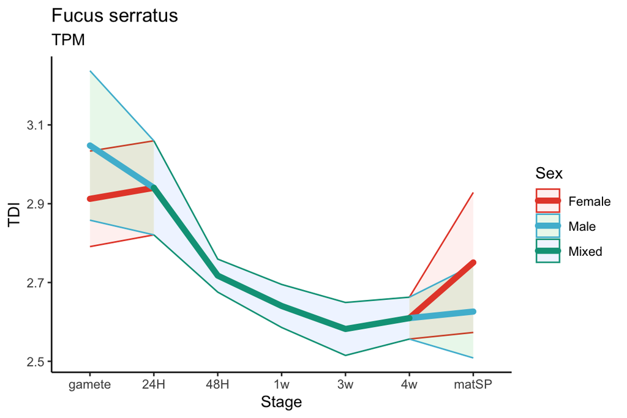

```r
Fs_TDI %>%
  ggplot2::ggplot(
    aes(
      y = TDI,
      x = Stage,
      group = Sex,
      colour = Sex,
      fill = Sex)) +
  ggplot2::geom_ribbon(
    aes(ymin = TDI - sd,
        ymax = TDI + sd
        ), alpha = 0.1) +
  ggplot2::geom_line(size = 2, lineend = "round") +
  theme_classic() +
  ggsci::scale_colour_npg() +
  labs(title = "Fucus serratus",
       subtitle = "TPM")
```

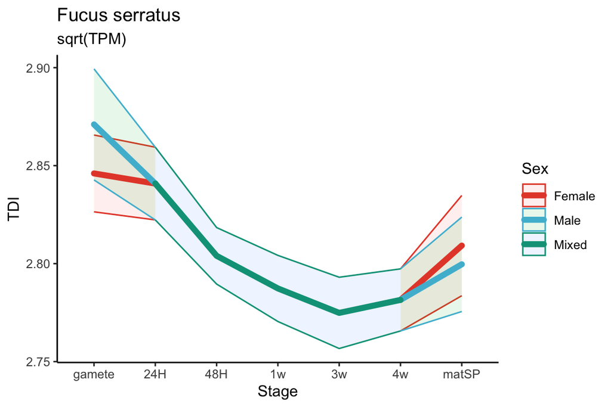

```r
Fs_TDI.sqrt %>%
  ggplot2::ggplot(
    aes(
      y = TDI,
      x = Stage,
      group = Sex,
      colour = Sex,
      fill = Sex)) +
  ggplot2::geom_ribbon(
    aes(ymin = TDI - sd,
        ymax = TDI + sd
        ), alpha = 0.1) +
  ggplot2::geom_line(size = 2, lineend = "round") +
  theme_classic() +
  ggsci::scale_colour_npg() +
  labs(title = "Fucus serratus",
       subtitle = "sqrt(TPM)")
```

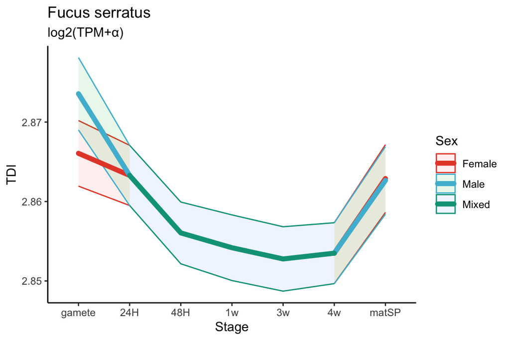

```r
Fs_TDI.log2 %>%
  ggplot2::ggplot(
    aes(
      y = TDI,
      x = Stage,
      group = Sex,
      colour = Sex,
      fill = Sex)) +
  ggplot2::geom_ribbon(
    aes(ymin = TDI - sd,
        ymax = TDI + sd
        ), alpha = 0.1) +
  ggplot2::geom_line(size = 2, lineend = "round") +
  theme_classic() +
  ggsci::scale_colour_npg() +
  labs(title = "Fucus serratus",
       subtitle = "log2(TPM+\u03b1)")
```

## Fucus distichus

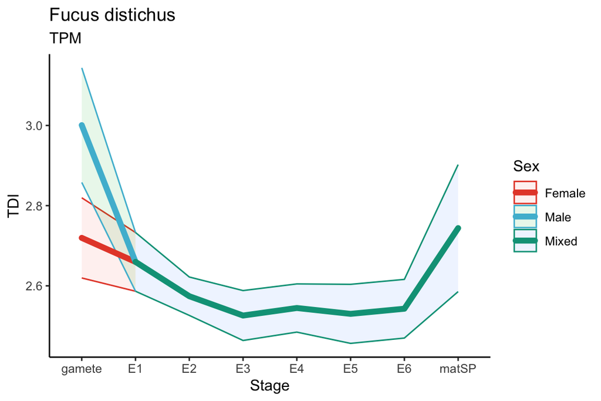

```r
Fd_TDI %>%
  ggplot2::ggplot(
    aes(
      y = TDI,
      x = Stage,
      group = Sex,
      colour = Sex,
      fill = Sex)) +
  ggplot2::geom_ribbon(
    aes(ymin = TDI - sd,
        ymax = TDI + sd
        ), alpha = 0.1) +
  ggplot2::geom_line(size = 2, lineend = "round") +
  theme_classic() +
  ggsci::scale_colour_npg() +
  labs(title = "Fucus distichus",
       subtitle = "TPM")
```

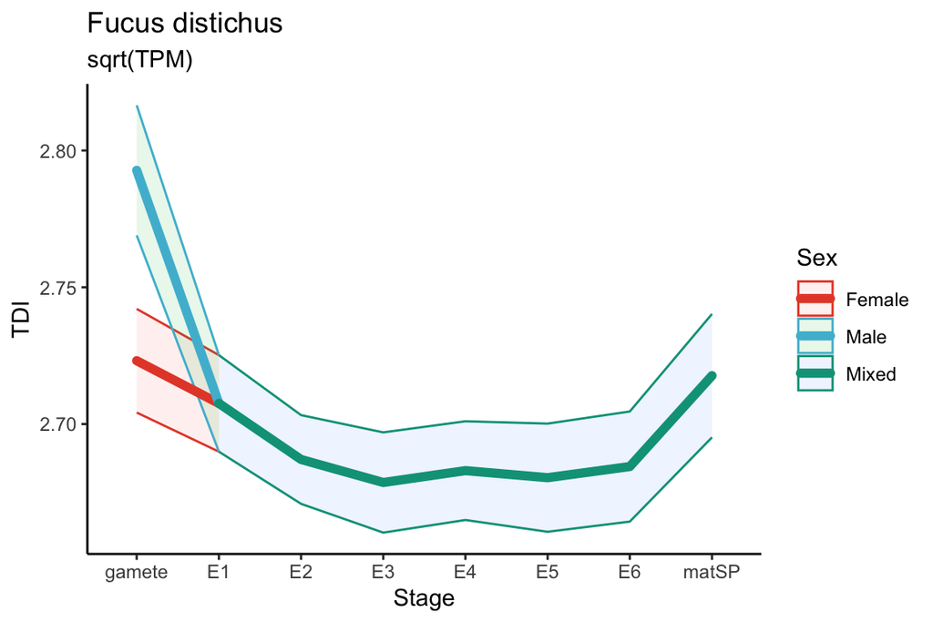

```r
Fd_TDI.sqrt %>%
  ggplot2::ggplot(
    aes(
      y = TDI,
      x = Stage,
      group = Sex,
      colour = Sex,
      fill = Sex)) +
  ggplot2::geom_ribbon(
    aes(ymin = TDI - sd,
        ymax = TDI + sd
        ), alpha = 0.1) +
  ggplot2::geom_line(size = 2, lineend = "round") +
  theme_classic() +
  ggsci::scale_colour_npg() +
  labs(title = "Fucus distichus",
       subtitle = "sqrt(TPM)")
```

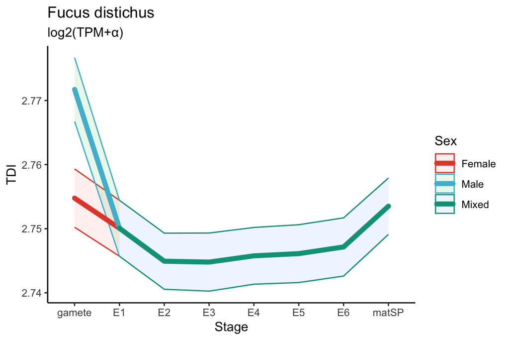

```r
Fd_TDI.log2 %>%
  ggplot2::ggplot(
    aes(
      y = TDI,
      x = Stage,
      group = Sex,
      colour = Sex,
      fill = Sex)) +
  ggplot2::geom_ribbon(
    aes(ymin = TDI - sd,
        ymax = TDI + sd
        ), alpha = 0.1) +
  ggplot2::geom_line(size = 2, lineend = "round") +
  theme_classic() +
  ggsci::scale_colour_npg() +
  labs(title = "Fucus distichus",
       subtitle = "log2(TPM+\u03b1)")
```

## TDI *Fucus* embryonic stages only

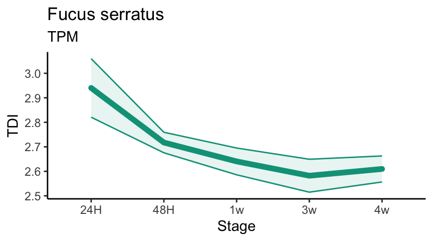

```r
#Fs
Fs_TDI %>%
  dplyr::filter(Stage %in% c("24H", "48H", "1w", "3w", "4w") & Sex == "Mixed") %>%
  ggplot2::ggplot(
    aes(
      y = TDI,
      x = Stage,
      group = 1)) +
  ggplot2::geom_ribbon(
    aes(ymin = TDI - sd,
        ymax = TDI + sd
        ),
    colour = "#00A087FF",
    fill = "#00A087FF",
    alpha = 0.1) +
  ggplot2::geom_line(
    size = 2,
    lineend = "round",
    colour = "#00A087FF") +
  theme_classic() +
  ggsci::scale_colour_npg() +
  labs(title = "Fucus serratus",
       subtitle = "TPM")
```

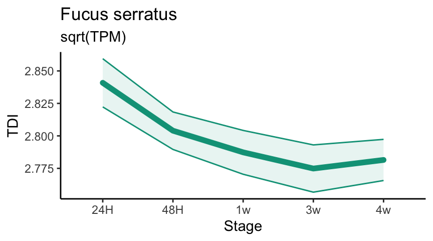

```r
Fs_TDI.sqrt %>%
  dplyr::filter(Stage %in% c("24H", "48H", "1w", "3w", "4w") & Sex == "Mixed") %>%
  ggplot2::ggplot(
    aes(
      y = TDI,
      x = Stage,
      group = 1)) +
  ggplot2::geom_ribbon(
    aes(ymin = TDI - sd,
        ymax = TDI + sd
        ),
    colour = "#00A087FF",
    fill = "#00A087FF",
    alpha = 0.1) +
  ggplot2::geom_line(
    size = 2,
    lineend = "round",
    colour = "#00A087FF") +
  theme_classic() +
  ggsci::scale_colour_npg() +
  labs(title = "Fucus serratus",
       subtitle = "sqrt(TPM)")
```

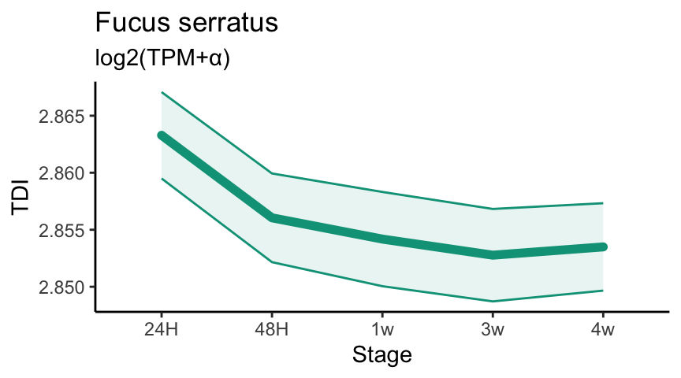

```r
Fs_TDI.log2 %>%
  dplyr::filter(Stage %in% c("24H", "48H", "1w", "3w", "4w") & Sex == "Mixed") %>%
  ggplot2::ggplot(
    aes(
      y = TDI,
      x = Stage,
      group = 1)) +
  ggplot2::geom_ribbon(
    aes(ymin = TDI - sd,
        ymax = TDI + sd
        ),
    colour = "#00A087FF",
    fill = "#00A087FF",
    alpha = 0.1) +
  ggplot2::geom_line(
    size = 2,
    lineend = "round",
    colour = "#00A087FF") +
  theme_classic() +
  ggsci::scale_colour_npg() +
  labs(title = "Fucus serratus",
       subtitle = "log2(TPM+\u03b1)")
```

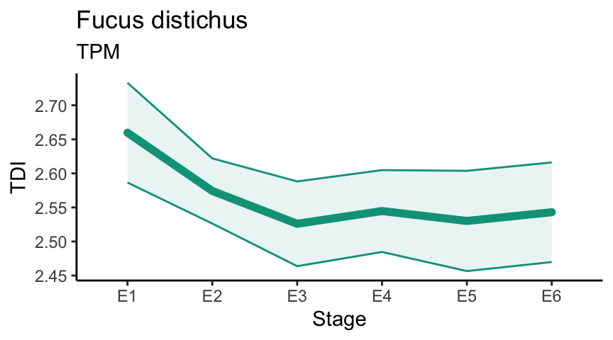

```r
# Fd
Fd_TDI %>%
  dplyr::filter(Stage %in% c("E1", "E2", "E3", "E4", "E5", "E6") & Sex == "Mixed") %>%
  ggplot2::ggplot(
    aes(
      y = TDI,
      x = Stage,
      group = 1)) +
  ggplot2::geom_ribbon(
    aes(ymin = TDI - sd,
        ymax = TDI + sd
        ),
    colour = "#00A087FF",
    fill = "#00A087FF",
    alpha = 0.1) +
  ggplot2::geom_line(
    size = 2,
    lineend = "round",
    colour = "#00A087FF") +
  theme_classic() +
  ggsci::scale_colour_npg() +
  labs(title = "Fucus distichus",
       subtitle = "TPM")
```

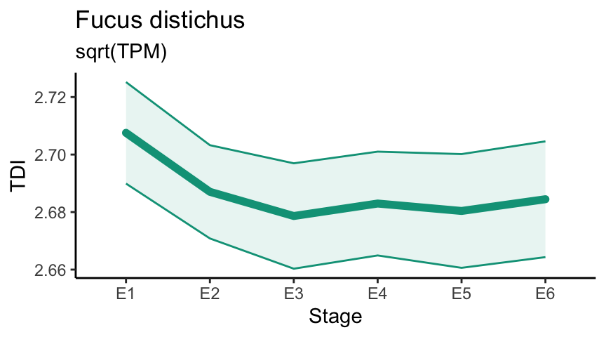

```r
Fd_TDI.sqrt %>%
  dplyr::filter(Stage %in% c("E1", "E2", "E3", "E4", "E5", "E6") & Sex == "Mixed") %>%
  ggplot2::ggplot(
    aes(
      y = TDI,
      x = Stage,
      group = 1)) +
  ggplot2::geom_ribbon(
    aes(ymin = TDI - sd,
        ymax = TDI + sd
        ),
    colour = "#00A087FF",
    fill = "#00A087FF",
    alpha = 0.1) +
  ggplot2::geom_line(
    size = 2,
    lineend = "round",
    colour = "#00A087FF") +
  theme_classic() +
  ggsci::scale_colour_npg() +
  labs(title = "Fucus distichus",
       subtitle = "sqrt(TPM)")
```

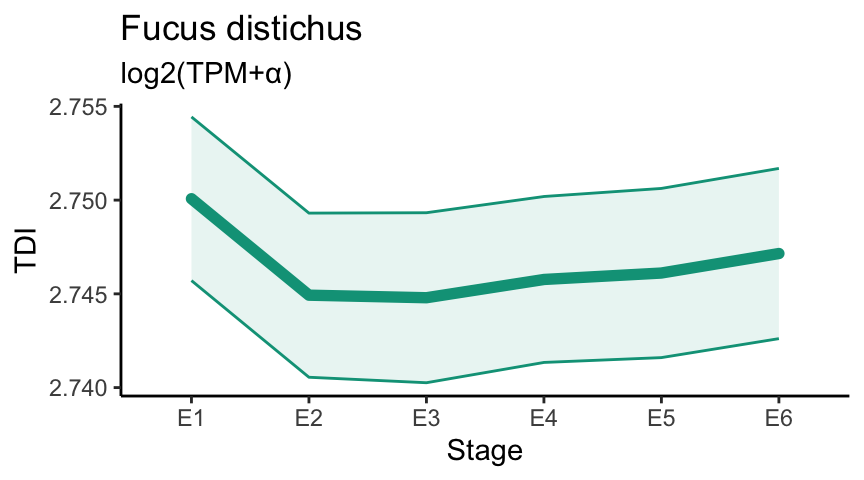

```r
Fd_TDI.log2 %>%
  dplyr::filter(Stage %in% c("E1", "E2", "E3", "E4", "E5", "E6") & Sex == "Mixed") %>%
  ggplot2::ggplot(
    aes(
      y = TDI,
      x = Stage,
      group = 1)) +
  ggplot2::geom_ribbon(
    aes(ymin = TDI - sd,
        ymax = TDI + sd
        ),
    colour = "#00A087FF",
    fill = "#00A087FF",
    alpha = 0.1) +
  ggplot2::geom_line(
    size = 2,
    lineend = "round",
    colour = "#00A087FF") +
  theme_classic() +
  ggsci::scale_colour_npg() +
  labs(title = "Fucus distichus",
       subtitle = "log2(TPM+\u03b1)")
```

## Ectocarpus

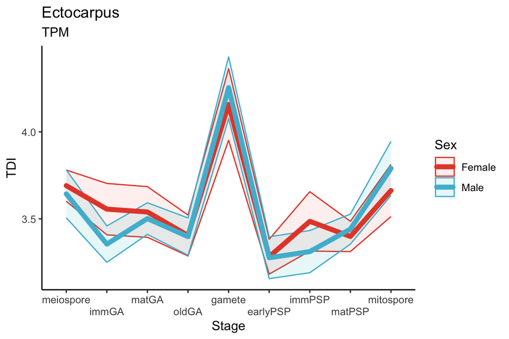

```r
Ec_TDI %>%
  ggplot2::ggplot(
    aes(
      y = TDI,
      x = Stage,
      group = Sex,
      colour = Sex,
      fill = Sex)) +
  ggplot2::geom_ribbon(
    aes(ymin = TDI - sd,
        ymax = TDI + sd
        ), alpha = 0.1) +
  ggplot2::geom_line(size = 2, lineend = "round") +
  theme_classic() +
  ggsci::scale_colour_npg() +
  ggplot2::scale_x_discrete(guide = ggplot2::guide_axis(n.dodge=2)) +
  labs(title = "Ectocarpus",
       subtitle = "TPM")
```

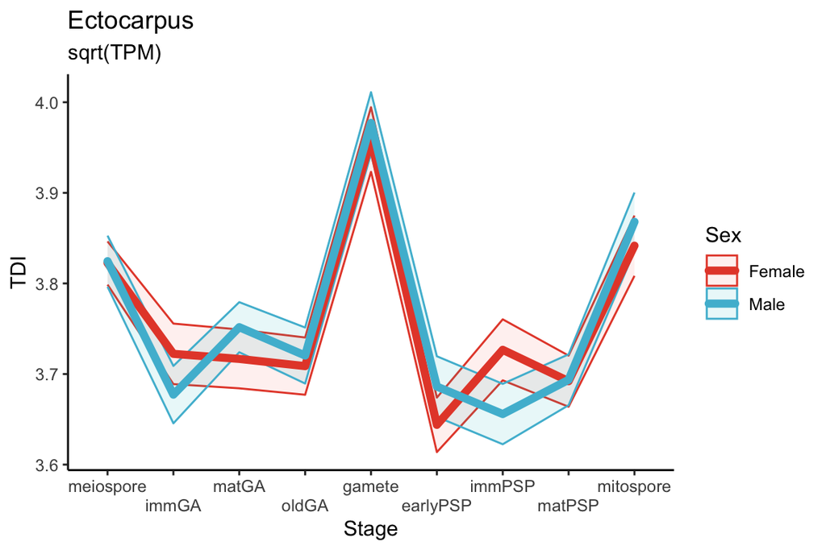

```r
Ec_TDI.sqrt %>%
  ggplot2::ggplot(
    aes(
      y = TDI,
      x = Stage,
      group = Sex,
      colour = Sex,
      fill = Sex)) +
  ggplot2::geom_ribbon(
    aes(ymin = TDI - sd,
        ymax = TDI + sd
        ), alpha = 0.1) +
  ggplot2::geom_line(size = 2, lineend = "round") +
  theme_classic() +
  ggsci::scale_colour_npg() +
  ggplot2::scale_x_discrete(guide = ggplot2::guide_axis(n.dodge=2)) +
  labs(title = "Ectocarpus",
       subtitle = "sqrt(TPM)")
```

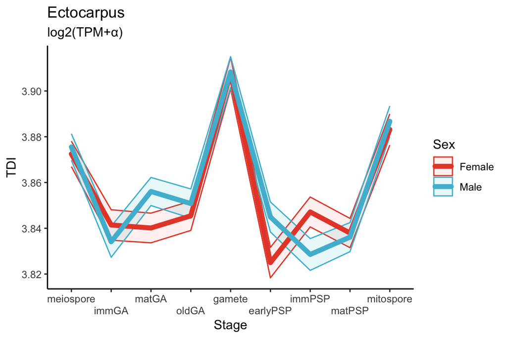

```r
Ec_TDI.log2 %>%
  ggplot2::ggplot(
    aes(
      y = TDI,
      x = Stage,
      group = Sex,
      colour = Sex,
      fill = Sex)) +
  ggplot2::geom_ribbon(
    aes(ymin = TDI - sd,
        ymax = TDI + sd
        ), alpha = 0.1) +
  ggplot2::geom_line(size = 2, lineend = "round") +
  theme_classic() +
  ggsci::scale_colour_npg() +
  ggplot2::scale_x_discrete(guide = ggplot2::guide_axis(n.dodge=2)) +
  labs(title = "Ectocarpus",
       subtitle = "log2(TPM+\u03b1)")
```

# tfStability

## Flat line test

*F. serratus*

```r
Fs_DES_tS <-
  tfStability(
    dplyr::select(Fs_DES, !c(gamete, matSP)),
    transforms = c("none", "sqrt", "log2", "rank"),
    permutations = 50000
    )
Fs_DES_tS_processed <-
  tibble::as_tibble(Fs_DES_tS, rownames = "transformation")

Fs_DES_tS_res <-
  Fs_DES_tS_processed %>%
  dplyr::rename("pval" = value) %>%
  dplyr::mutate(test = "FlatLineTest")
```

*F. distichus*

```r
Fd_DES_tS <-
  tfStability(
    dplyr::select(Fd_DES, !c(gamete, matSP)),
    transforms = c("none", "sqrt", "log2", "rank"),
    permutations = 50000
    )
Fd_DES_tS_processed <-
  tibble::as_tibble(Fd_DES_tS, rownames = "transformation")

Fd_DES_tS_res <-
  Fd_DES_tS_processed %>%
  dplyr::rename("pval" = value) %>%
  dplyr::mutate(test = "FlatLineTest")
```

*Ectocarpus*

```r
# female
Ec_DES_25f_tS <-
  tfStability(
    Ec_DES_25f,
    transforms = c("none", "sqrt", "log2", "rank"),
    permutations = 50000
    )
Ec_DES_25f_tS_processed <-
  tibble::as_tibble(Ec_DES_25f_tS, rownames = "transformation")

Ec_DES_25f_tS_res <-
  Ec_DES_25f_tS_processed %>%
  dplyr::rename("pval" = value) %>%
  dplyr::mutate(test = "FlatLineTest")

# male
Ec_DES_32m_tS <-
  tfStability(
    Ec_DES_32m,
    transforms = c("none", "sqrt", "log2", "rank"),
    permutations = 50000
    )
Ec_DES_32m_tS_processed <-
  tibble::as_tibble(Ec_DES_32m_tS, rownames = "transformation")

Ec_DES_32m_tS_res <-
  Ec_DES_32m_tS_processed %>%
  dplyr::rename("pval" = value) %>%
  dplyr::mutate(test = "FlatLineTest")
```

### Plot p-values

Fucus serratus development

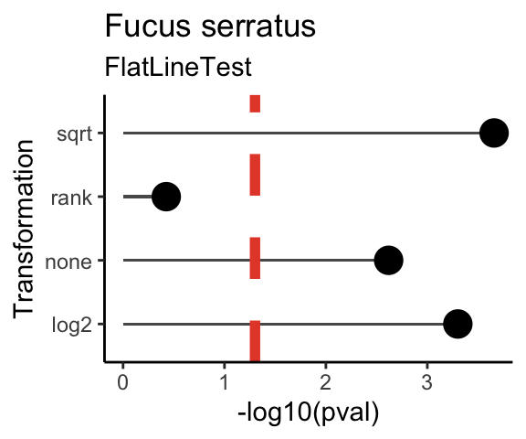

```r
Fs_DES_tS_res %>%
  ggplot2::ggplot(
    aes(
      y = -log10(pval),
      x = transformation)) +
  ggplot2::geom_col(width = 0.05) +
  ggplot2::geom_point(size = 5) +
  ggplot2::geom_hline(
    yintercept = -log10(0.05),
    colour = "#E64B35FF",
    linetype = 'dashed',
    size = 2
    ) +
  # ggplot2::annotate(
  #   "label",
  #   x = 0.7,
  #   y = max(-log10(Fs_DES_tS_res$pval))/6,
  #   label = "pval < 0.05",
  #   # angle = 270,
  #   colour = "#E64B35FF") +
  ggplot2::labs(
    title = "Fucus serratus",
    subtitle = "FlatLineTest",
    x = "Transformation"
  ) +
  ggplot2::coord_flip() +
  ggplot2::theme_classic()
```

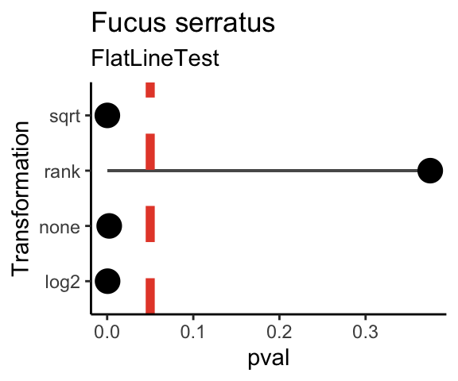

```r
# or perhaps we can use raw Pvalues
Fs_DES_tS_res %>%
  ggplot2::ggplot(
    aes(
      y = pval,
      x = transformation)) +
  ggplot2::geom_col(width = 0.05) +
  ggplot2::geom_point(size = 5) +
  ggplot2::geom_hline(
    yintercept = 0.05,
    colour = "#E64B35FF",
    linetype = 'dashed',
    size = 2
    ) +
  # ggplot2::annotate(
  #   "label",
  #   x = 1.5,
  #   y = 0.05 - 0.005,
  #   label = "pval < 0.05",
  #   # angle = 270,
  #   colour = "#E64B35FF") +
  ggplot2::labs(
    title = "Fucus serratus",
    subtitle = "FlatLineTest",
    x = "Transformation"
  ) +
  ggplot2::coord_flip() +
  ggplot2::theme_classic()
```

Fucus distichus development

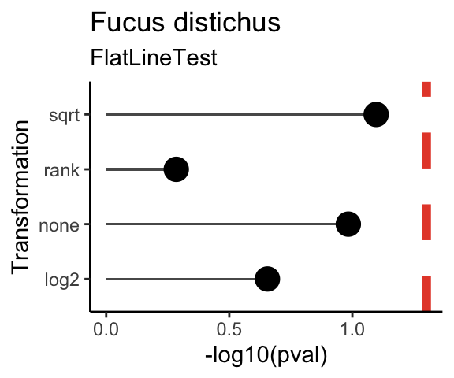

```r
Fd_DES_tS_res %>%
  ggplot2::ggplot(
    aes(
      y = -log10(pval),
      x = transformation)) +
  ggplot2::geom_col(width = 0.05) +
  ggplot2::geom_point(size = 5) +
  ggplot2::geom_hline(
    yintercept = -log10(0.05),
    colour = "#E64B35FF",
    linetype = 'dashed',
    size = 2
    ) +
  # ggplot2::annotate(
  #   "label",
  #   x = 0.7,
  #   y = max(-log10(Fd_DES_tS_res$pval))/6,
  #   label = "pval < 0.05",
  #   # angle = 270,
  #   colour = "#E64B35FF") +
  ggplot2::labs(
    title = "Fucus distichus",
    subtitle = "FlatLineTest",
    x = "Transformation"
  ) +
  ggplot2::coord_flip() +
  ggplot2::theme_classic()
```

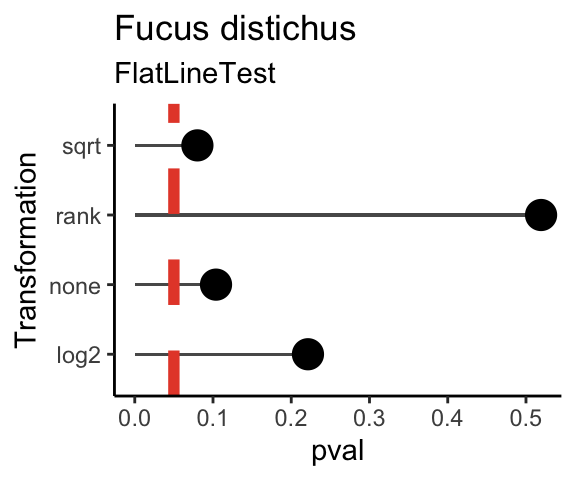

```r
# or perhaps we can use raw Pvalues
Fd_DES_tS_res %>%
  ggplot2::ggplot(
    aes(
      y = pval,
      x = transformation)) +
  ggplot2::geom_col(width = 0.05) +
  ggplot2::geom_point(size = 5) +
  ggplot2::geom_hline(
    yintercept = 0.05,
    colour = "#E64B35FF",
    linetype = 'dashed',
    size = 2
    ) +
  # ggplot2::annotate(
  #   "label",
  #   x = 1.5,
  #   y = 0.05 - 0.005,
  #   label = "pval < 0.05",
  #   # angle = 270,
  #   colour = "#E64B35FF") +
  ggplot2::labs(
    title = "Fucus distichus",
    subtitle = "FlatLineTest",
    x = "Transformation"
  ) +
  ggplot2::coord_flip() +
  ggplot2::theme_classic()
```

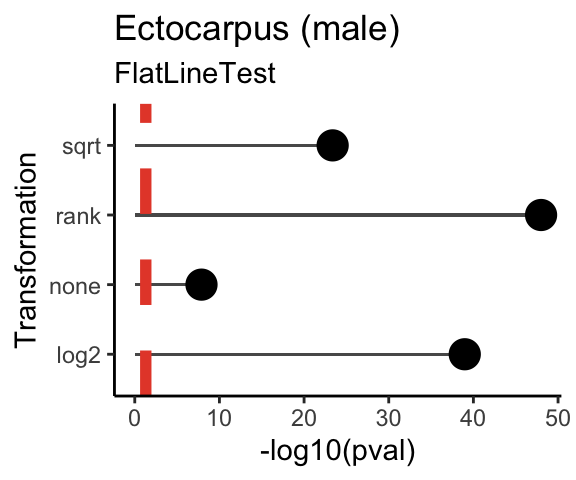

```r
Ec_DES_32m_tS_res %>%
  ggplot2::ggplot(
    aes(
      y = -log10(pval),
      x = transformation)) +
  ggplot2::geom_col(width = 0.05) +
  ggplot2::geom_point(size = 5) +
  ggplot2::geom_hline(
    yintercept = -log10(0.05),
    colour = "#E64B35FF",
    linetype = 'dashed',
    size = 2
    ) +
  # ggplot2::annotate(
  #   "label",
  #   x = 0.7,
  #   y = max(-log10(Ec_DES_32m_tS_res$pval))/6,
  #   label = "pval < 0.05",
  #   # angle = 270,
  #   colour = "#E64B35FF") +
  ggplot2::labs(
    title = "Ectocarpus (male)",
    subtitle = "FlatLineTest",
    x = "Transformation"
  ) +
  ggplot2::coord_flip() +
  ggplot2::theme_classic()
```

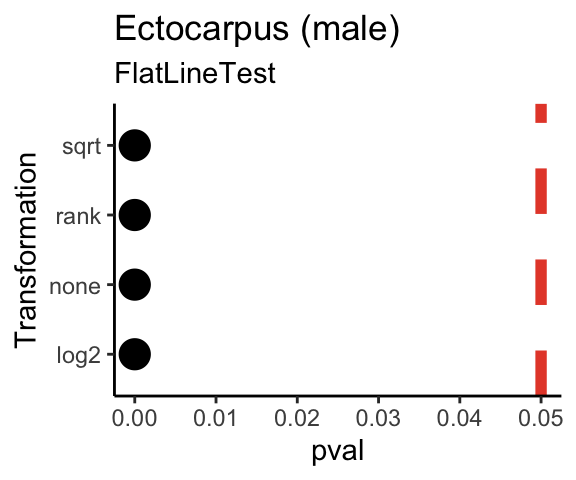

```r
Ec_DES_32m_tS_res %>%
  ggplot2::ggplot(
    aes(
      y = pval,
      x = transformation)) +
  ggplot2::geom_col(width = 0.05) +
  ggplot2::geom_point(size = 5) +
  ggplot2::geom_hline(
    yintercept = 0.05,
    colour = "#E64B35FF",
    linetype = 'dashed',
    size = 2
    ) +
  # ggplot2::annotate(
  #   "label",
  #   x = 1.5,
  #   y = 0.05 - 0.005,
  #   label = "pval < 0.05",
  #   # angle = 270,
  #   colour = "#E64B35FF") +
  ggplot2::labs(
    title = "Ectocarpus (male)",
    subtitle = "FlatLineTest",
    x = "Transformation"
  ) +
  ggplot2::coord_flip() +
  ggplot2::theme_classic()
```

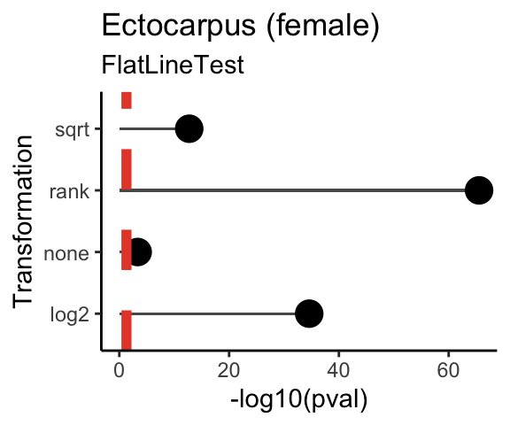

```r
Ec_DES_25f_tS_res %>%
  ggplot2::ggplot(
    aes(
      y = -log10(pval),
      x = transformation)) +
  ggplot2::geom_col(width = 0.05) +
  ggplot2::geom_point(size = 5) +
  ggplot2::geom_hline(
    yintercept = -log10(0.05),
    colour = "#E64B35FF",
    linetype = 'dashed',
    size = 2
    ) +
  # ggplot2::annotate(
  #   "label",
  #   x = 0.7,
  #   y = max(-log10(Ec_DES_25f_tS_res$pval))/6,
  #   label = "pval < 0.05",
  #   # angle = 270,
  #   colour = "#E64B35FF") +
  ggplot2::labs(
    title = "Ectocarpus (female)",
    subtitle = "FlatLineTest",
    x = "Transformation"
  ) +
  ggplot2::coord_flip() +
  ggplot2::theme_classic()
```

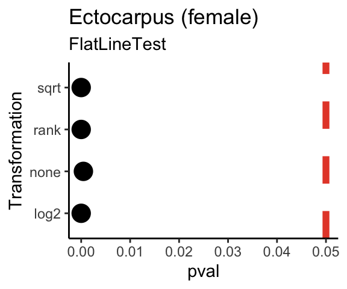

```r
Ec_DES_25f_tS_res %>%
  ggplot2::ggplot(
    aes(
      y = pval,
      x = transformation)) +
  ggplot2::geom_col(width = 0.05) +
  ggplot2::geom_point(size = 5) +
  ggplot2::geom_hline(
    yintercept = 0.05,
    colour = "#E64B35FF",
    linetype = 'dashed',
    size = 2
    ) +
  # ggplot2::annotate(
  #   "label",
  #   x = 1.5,
  #   y = 0.05 - 0.005,
  #   label = "pval < 0.05",
  #   # angle = 270,
  #   colour = "#E64B35FF") +
  ggplot2::labs(
    title = "Ectocarpus (female)",
    subtitle = "FlatLineTest",
    x = "Transformation"
  ) +
  ggplot2::coord_flip() +
  ggplot2::theme_classic()
```

## Non-flat line profile

```r
Fs_DES_tS <-
  tfStability(
    dplyr::select(Fs_DES, !c(gamete, matSP)),
    TestStatistic = "ReductiveHourglassTest",
    transforms = c("none", "sqrt", "log2", "rank"),
    modules = list(early = 1:2, mid = 3:4, late = 5),
    permutations = 50000
    )
```

```
## Proceeding with the ReductiveHourglassTest
```

```
## The phylotranscriptomic pattern may not follow an hourglass pattern (high-low-high).
```

```r
Fs_DES_tS_processed <-
  tibble::as_tibble(Fs_DES_tS, rownames = "transformation")

Fs_DES_tS_res <-
  Fs_DES_tS_processed %>%
  dplyr::rename("pval" = value) %>%
  dplyr::mutate(test = "ReductiveHourglassTest")

Fd_DES_tS <-
  tfStability(
    dplyr::select(Fd_DES, !c(gamete, matSP)),
    TestStatistic = "ReductiveHourglassTest",
    transforms = c("none", "sqrt", "log2", "rank"),
    modules = list(early = 1:4, mid = 5, late = 6),
    permutations = 50000
    )
```

```
## Proceeding with the ReductiveHourglassTest
## The phylotranscriptomic pattern may not follow an hourglass pattern (high-low-high).
```

```r
Fd_DES_tS_processed <-
  tibble::as_tibble(Fd_DES_tS, rownames = "transformation")

Fd_DES_tS_res <-
  Fd_DES_tS_processed %>%
  dplyr::rename("pval" = value) %>%
  dplyr::mutate(test = "ReductiveHourglassTest")
```

### Plot p-values

Fucus serratus development

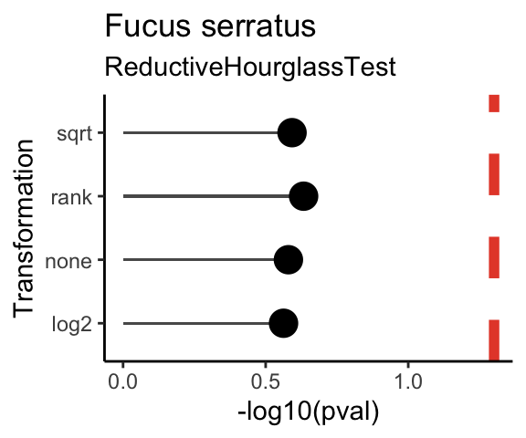

```r
Fs_DES_tS_res %>%
  ggplot2::ggplot(
    aes(
      y = -log10(pval),
      x = transformation)) +
  ggplot2::geom_col(width = 0.05) +
  ggplot2::geom_point(size = 5) +
  ggplot2::geom_hline(
    yintercept = -log10(0.05),
    colour = "#E64B35FF",
    linetype = 'dashed',
    size = 2
    ) +
  # ggplot2::annotate(
  #   "label",
  #   x = 0.7,
  #   y = max(-log10(Fs_DES_tS_res$pval))/6,
  #   label = "pval < 0.05",
  #   # angle = 270,
  #   colour = "#E64B35FF") +
  ggplot2::labs(
    title = "Fucus serratus",
    subtitle = "ReductiveHourglassTest",
    x = "Transformation"
  ) +
  ggplot2::coord_flip() +
  ggplot2::theme_classic()
```

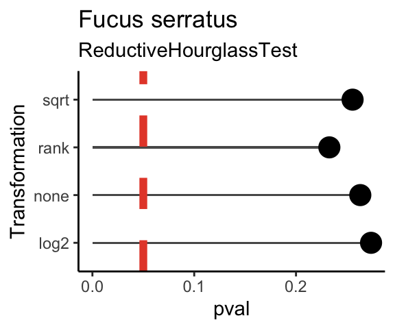

```r
# or perhaps we can use raw Pvalues
Fs_DES_tS_res %>%
  ggplot2::ggplot(
    aes(
      y = pval,
      x = transformation)) +
  ggplot2::geom_col(width = 0.05) +
  ggplot2::geom_point(size = 5) +
  ggplot2::geom_hline(
    yintercept = 0.05,
    colour = "#E64B35FF",
    linetype = 'dashed',
    size = 2
    ) +
  # ggplot2::annotate(
  #   "label",
  #   x = 1.5,
  #   y = 0.05 - 0.005,
  #   label = "pval < 0.05",
  #   # angle = 270,
  #   colour = "#E64B35FF") +
  ggplot2::labs(
    title = "Fucus serratus",
    subtitle = "ReductiveHourglassTest",
    x = "Transformation"
  ) +
  ggplot2::coord_flip() +
  ggplot2::theme_classic()
```

Fucus distichus development

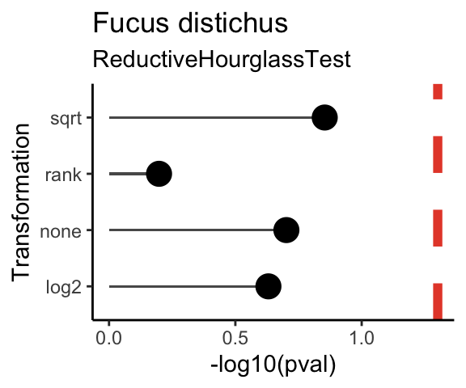

```r
Fd_DES_tS_res %>%
  ggplot2::ggplot(
    aes(
      y = -log10(pval),
      x = transformation)) +
  ggplot2::geom_col(width = 0.05) +
  ggplot2::geom_point(size = 5) +
  ggplot2::geom_hline(
    yintercept = -log10(0.05),
    colour = "#E64B35FF",
    linetype = 'dashed',
    size = 2
    ) +
  # ggplot2::annotate(
  #   "label",
  #   x = 0.7,
  #   y = max(-log10(Fd_DES_tS_res$pval))/6,
  #   label = "pval < 0.05",
  #   # angle = 270,
  #   colour = "#E64B35FF") +
  ggplot2::labs(
    title = "Fucus distichus",
    subtitle = "ReductiveHourglassTest",
    x = "Transformation"
  ) +
  ggplot2::coord_flip() +
  ggplot2::theme_classic()
```

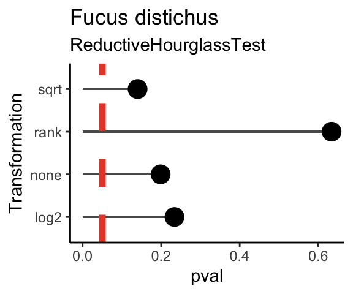

```r
# y = -log10(0.05) + max(Fd_DES_tS_res)/9,
# or perhaps we can use raw Pvalues
Fd_DES_tS_res %>%
  ggplot2::ggplot(
    aes(
      y = pval,
      x = transformation)) +
  ggplot2::geom_col(width = 0.05) +
  ggplot2::geom_point(size = 5) +
  ggplot2::geom_hline(
    yintercept = 0.05,
    colour = "#E64B35FF",
    linetype = 'dashed',
    size = 2
    ) +
  # ggplot2::annotate(
  #   "label",
  #   x = 1.5,
  #   y = 0.05 - 0.005,
  #   label = "pval < 0.05",
  #   # angle = 270,
  #   colour = "#E64B35FF") +
  ggplot2::labs(
    title = "Fucus distichus",
    subtitle = "ReductiveHourglassTest",
    x = "Transformation"
  ) +
  ggplot2::coord_flip() +
  ggplot2::theme_classic()
```